# Class 10 - Lecture

Hari Subhash

Date created: 2019-04-11

**LEARNING OBJECTIVE**: Explore data effectively using a checklist

**TOPICS TO COVER**

1. Next assignment: Explore the causes of departure and arrival delays
2. Formulate your initial question
3. Examine your data sources
   - `str()`, `glimpse()`, `summary()`, `skim()`
   - Check the top and bottom of your data
4. Examine the variables of interest for your question
5. Explore a solution for your question
   - Use visual comparisons
   - Illustrate causal frameworks
   - Use multivariate comparisons
6. Try and invalidate your solution
7. Reformulate your question (Rinse and repeat)
8. Integrate different modes of presenting evidence

## Formulate your initial question

We would like to explore the relationship between departure delay and weather?

There is a relationship between departure delays and weather

There is a relationship between departure delay and inclement weather

Which weather variable has the strongest impact on departure delay?

The last question in being specific is also disregarding other potential causes of departure delay.

## Examine your data sources

We have two data sources that we will be using - `flights` and `weather`. So first lets take a look at them.

Here is the flights data printed.

```r
library(tidyverse); library(nycflights13)
flights
```

| year | month | day | dep_time | sched_dep_time | dep_delay | arr_time | sched_arr_time | arr_delay | carrier | flight | tailnum | origin | dest | air_time | distance | hour | minute | time_hour |
| --- | --- | --- | --- | --- | --- | --- | --- | --- | --- | --- | --- | --- | --- | --- | --- | --- | --- | --- |
| 2013 | 1 | 1 | 517 | 515 | 2 | 830 | 819 | 11 | UA | 1545 | N14228 | EWR | IAH | 227 | 1400 | 5 | 15 | 2013-01-01 05:00:00 |
| 2013 | 1 | 1 | 533 | 529 | 4 | 850 | 830 | 20 | UA | 1714 | N24211 | LGA | IAH | 227 | 1416 | 5 | 29 | 2013-01-01 05:00:00 |
| 2013 | 1 | 1 | 542 | 540 | 2 | 923 | 850 | 33 | AA | 1141 | N619AA | JFK | MIA | 160 | 1089 | 5 | 40 | 2013-01-01 05:00:00 |
| 2013 | 1 | 1 | 544 | 545 | -1 | 1004 | 1022 | -18 | B6 | 725 | N804JB | JFK | BQN | 183 | 1576 | 5 | 45 | 2013-01-01 05:00:00 |
| 2013 | 1 | 1 | 554 | 600 | -6 | 812 | 837 | -25 | DL | 461 | N668DN | LGA | ATL | 116 | 762 | 6 | 0 | 2013-01-01 06:00:00 |
| 2013 | 1 | 1 | 554 | 558 | -4 | 740 | 728 | 12 | UA | 1696 | N39463 | EWR | ORD | 150 | 719 | 5 | 58 | 2013-01-01 05:00:00 |
| 2013 | 1 | 1 | 555 | 600 | -5 | 913 | 854 | 19 | B6 | 507 | N516JB | EWR | FLL | 158 | 1065 | 6 | 0 | 2013-01-01 06:00:00 |
| 2013 | 1 | 1 | 557 | 600 | -3 | 709 | 723 | -14 | EV | 5708 | N829AS | LGA | IAD | 53 | 229 | 6 | 0 | 2013-01-01 06:00:00 |
| 2013 | 1 | 1 | 557 | 600 | -3 | 838 | 846 | -8 | B6 | 79 | N593JB | JFK | MCO | 140 | 944 | 6 | 0 | 2013-01-01 06:00:00 |
| 2013 | 1 | 1 | 558 | 600 | -2 | 753 | 745 | 8 | AA | 301 | N3ALAA | LGA | ORD | 138 | 733 | 6 | 0 | 2013-01-01 06:00:00 |

[output cut: 990 more lines]

You can also look at the structure of the flights data using the `str()` command. This gives us a bit more detail about the data.

```r
str(flights)
```

```
Classes ‘tbl_df’, ‘tbl’ and 'data.frame':   336776 obs. of  19 variables:
 $ year          : int  2013 2013 2013 2013 2013 2013 2013 2013 2013 2013 ...
 $ month         : int  1 1 1 1 1 1 1 1 1 1 ...
 $ day           : int  1 1 1 1 1 1 1 1 1 1 ...
 $ dep_time      : int  517 533 542 544 554 554 555 557 557 558 ...
 $ sched_dep_time: int  515 529 540 545 600 558 600 600 600 600 ...
 $ dep_delay     : num  2 4 2 -1 -6 -4 -5 -3 -3 -2 ...
 $ arr_time      : int  830 850 923 1004 812 740 913 709 838 753 ...
 $ sched_arr_time: int  819 830 850 1022 837 728 854 723 846 745 ...
 $ arr_delay     : num  11 20 33 -18 -25 12 19 -14 -8 8 ...
 $ carrier       : chr  "UA" "UA" "AA" "B6" ...
 $ flight        : int  1545 1714 1141 725 461 1696 507 5708 79 301 ...
 $ tailnum       : chr  "N14228" "N24211" "N619AA" "N804JB" ...
 $ origin        : chr  "EWR" "LGA" "JFK" "JFK" ...
 $ dest          : chr  "IAH" "IAH" "MIA" "BQN" ...
 $ air_time      : num  227 227 160 183 116 150 158 53 140 138 ...
 $ distance      : num  1400 1416 1089 1576 762 ...
 $ hour          : num  5 5 5 5 6 5 6 6 6 6 ...
 $ minute        : num  15 29 40 45 0 58 0 0 0 0 ...
 $ time_hour     : POSIXct, format: "2013-01-01 05:00:00" "2013-01-01 05:00:00" ...
```

A similar command is `glimpse()` from `dplyr`.

```r
glimpse(flights)
```

```
Observations: 336,776
Variables: 19
$ year           <int> 2013, 2013, 2013, 2013, 2013, 2013, 2013, 2013, 2013, 2013, 201…
$ month          <int> 1, 1, 1, 1, 1, 1, 1, 1, 1, 1, 1, 1, 1, 1, 1, 1, 1, 1, 1, 1, 1, …
$ day            <int> 1, 1, 1, 1, 1, 1, 1, 1, 1, 1, 1, 1, 1, 1, 1, 1, 1, 1, 1, 1, 1, …
$ dep_time       <int> 517, 533, 542, 544, 554, 554, 555, 557, 557, 558, 558, 558, 558…
$ sched_dep_time <int> 515, 529, 540, 545, 600, 558, 600, 600, 600, 600, 600, 600, 600…
$ dep_delay      <dbl> 2, 4, 2, -1, -6, -4, -5, -3, -3, -2, -2, -2, -2, -2, -1, 0, -1,…
$ arr_time       <int> 830, 850, 923, 1004, 812, 740, 913, 709, 838, 753, 849, 853, 92…
$ sched_arr_time <int> 819, 830, 850, 1022, 837, 728, 854, 723, 846, 745, 851, 856, 91…
$ arr_delay      <dbl> 11, 20, 33, -18, -25, 12, 19, -14, -8, 8, -2, -3, 7, -14, 31, -…
$ carrier        <chr> "UA", "UA", "AA", "B6", "DL", "UA", "B6", "EV", "B6", "AA", "B6…
$ flight         <int> 1545, 1714, 1141, 725, 461, 1696, 507, 5708, 79, 301, 49, 71, 1…
$ tailnum        <chr> "N14228", "N24211", "N619AA", "N804JB", "N668DN", "N39463", "N5…
$ origin         <chr> "EWR", "LGA", "JFK", "JFK", "LGA", "EWR", "EWR", "LGA", "JFK", …
$ dest           <chr> "IAH", "IAH", "MIA", "BQN", "ATL", "ORD", "FLL", "IAD", "MCO", …
$ air_time       <dbl> 227, 227, 160, 183, 116, 150, 158, 53, 140, 138, 149, 158, 345,…
$ distance       <dbl> 1400, 1416, 1089, 1576, 762, 719, 1065, 229, 944, 733, 1028, 10…
$ hour           <dbl> 5, 5, 5, 5, 6, 5, 6, 6, 6, 6, 6, 6, 6, 6, 6, 5, 6, 6, 6, 6, 6, …
$ minute         <dbl> 15, 29, 40, 45, 0, 58, 0, 0, 0, 0, 0, 0, 0, 0, 0, 59, 0, 0, 0, …
$ time_hour      <dttm> 2013-01-01 05:00:00, 2013-01-01 05:00:00, 2013-01-01 05:00:00,…
```

We can also see basic summary statistics about the variables in our data using the `summary()` command.

```r
summary(flights)
```

```
      year          month             day           dep_time    sched_dep_time
 Min.   :2013   Min.   : 1.000   Min.   : 1.00   Min.   :   1   Min.   : 106
 1st Qu.:2013   1st Qu.: 4.000   1st Qu.: 8.00   1st Qu.: 907   1st Qu.: 906
 Median :2013   Median : 7.000   Median :16.00   Median :1401   Median :1359
 Mean   :2013   Mean   : 6.549   Mean   :15.71   Mean   :1349   Mean   :1344
 3rd Qu.:2013   3rd Qu.:10.000   3rd Qu.:23.00   3rd Qu.:1744   3rd Qu.:1729
 Max.   :2013   Max.   :12.000   Max.   :31.00   Max.   :2400   Max.   :2359
                                                 NA's   :8255
   dep_delay          arr_time    sched_arr_time   arr_delay          carrier
 Min.   : -43.00   Min.   :   1   Min.   :   1   Min.   : -86.000   Length:336776
 1st Qu.:  -5.00   1st Qu.:1104   1st Qu.:1124   1st Qu.: -17.000   Class :character
 Median :  -2.00   Median :1535   Median :1556   Median :  -5.000   Mode  :character
 Mean   :  12.64   Mean   :1502   Mean   :1536   Mean   :   6.895
 3rd Qu.:  11.00   3rd Qu.:1940   3rd Qu.:1945   3rd Qu.:  14.000
 Max.   :1301.00   Max.   :2400   Max.   :2359   Max.   :1272.000
 NA's   :8255      NA's   :8713                  NA's   :9430
     flight       tailnum             origin              dest              air_time
 Min.   :   1   Length:336776      Length:336776      Length:336776      Min.   : 20.0
 1st Qu.: 553   Class :character   Class :character   Class :character   1st Qu.: 82.0
 Median :1496   Mode  :character   Mode  :character   Mode  :character   Median :129.0
 Mean   :1972                                                            Mean   :150.7
 3rd Qu.:3465                                                            3rd Qu.:192.0
 Max.   :8500                                                            Max.   :695.0
                                                                         NA's   :9430
    distance         hour           minute        time_hour
 Min.   :  17   Min.   : 1.00   Min.   : 0.00   Min.   :2013-01-01 05:00:00
 1st Qu.: 502   1st Qu.: 9.00   1st Qu.: 8.00   1st Qu.:2013-04-04 13:00:00
 Median : 872   Median :13.00   Median :29.00   Median :2013-07-03 10:00:00
 Mean   :1040   Mean   :13.18   Mean   :26.23   Mean   :2013-07-03 05:22:54
 3rd Qu.:1389   3rd Qu.:17.00   3rd Qu.:44.00   3rd Qu.:2013-10-01 07:00:00
 Max.   :4983   Max.   :23.00   Max.   :59.00   Max.   :2013-12-31 23:00:00
```

Finally, the `skim()` function brings most of these functions together with a single command that neatly displays the characteristics of our data with histograms. Going forwards this would be the only command you would need to use when beginning to explore your data.

```r
library(skimr)
skim(flights)
```

```
Skim summary statistics
 n obs: 336776
 n variables: 19

── Variable type:character ──────────────────────────────────────────────────────────────
 variable missing complete      n min max empty n_unique
  carrier       0   336776 336776   2   2     0       16
     dest       0   336776 336776   3   3     0      105
   origin       0   336776 336776   3   3     0        3
  tailnum    2512   334264 336776   5   6     0     4043

── Variable type:integer ────────────────────────────────────────────────────────────────
       variable missing complete      n    mean      sd   p0  p25  p50  p75 p100
       arr_time    8713   328063 336776 1502.05  533.26    1 1104 1535 1940 2400
            day       0   336776 336776   15.71    8.77    1    8   16   23   31
       dep_time    8255   328521 336776 1349.11  488.28    1  907 1401 1744 2400
         flight       0   336776 336776 1971.92 1632.47    1  553 1496 3465 8500
          month       0   336776 336776    6.55    3.41    1    4    7   10   12
 sched_arr_time       0   336776 336776 1536.38  497.46    1 1124 1556 1945 2359
 sched_dep_time       0   336776 336776 1344.25  467.34  106  906 1359 1729 2359
           year       0   336776 336776 2013       0    2013 2013 2013 2013 2013
     hist
 ▁▁▃▇▆▆▇▆
 ▇▇▇▇▆▇▇▇
 ▁▁▇▆▆▇▆▂
 ▇▅▂▃▂▁▁▁
 ▇▅▇▃▅▇▅▇
 ▁▁▂▇▆▇▇▆
 ▁▃▇▆▆▇▇▂
 ▁▁▁▇▁▁▁▁

── Variable type:numeric ────────────────────────────────────────────────────────────────
  variable missing complete      n    mean     sd  p0 p25 p50  p75 p100     hist
  air_time    9430   327346 336776  150.69  93.69  20  82 129  192  695 ▇▇▂▃▁▁▁▁
 arr_delay    9430   327346 336776    6.9   44.63 -86 -17  -5   14 1272 ▇▁▁▁▁▁▁▁
 dep_delay    8255   328521 336776   12.64  40.21 -43  -5  -2   11 1301 ▇▁▁▁▁▁▁▁
  distance       0   336776 336776 1039.91 733.23  17 502 872 1389 4983 ▆▇▂▂▁▁▁▁
      hour       0   336776 336776   13.18   4.66   1   9  13   17   23 ▁▃▇▆▅▇▇▂
    minute       0   336776 336776   26.23  19.3    0   8  29   44   59 ▇▂▃▃▅▂▃▅

── Variable type:POSIXct ────────────────────────────────────────────────────────────────
  variable missing complete      n        min        max     median n_unique
 time_hour       0   336776 336776 2013-01-01 2013-12-31 2013-07-03     6936
```

Now lets look at the weather data.

```r
skim(weather)
```

```
Skim summary statistics
 n obs: 26115
 n variables: 15

── Variable type:character ──────────────────────────────────────────────────────────────
 variable missing complete     n min max empty n_unique
   origin       0    26115 26115   3   3     0        3

── Variable type:integer ────────────────────────────────────────────────────────────────
 variable missing complete     n  mean   sd p0 p25 p50 p75 p100     hist
      day       0    26115 26115 15.68 8.76  1   8  16  23   31 ▇▇▇▇▆▇▇▆
     hour       0    26115 26115 11.49 6.91  0   6  11  17   23 ▇▇▇▇▇▇▇▇

── Variable type:numeric ────────────────────────────────────────────────────────────────
   variable missing complete     n      mean     sd      p0     p25     p50     p75
       dewp       1    26114 26115   41.44    19.39   -9.94   26.06   42.08   57.92
      humid       1    26114 26115   62.53    19.4    12.74   47.05   61.79   78.79
      month       0    26115 26115    6.5      3.44    1       4       7       9
     precip       0    26115 26115    0.0045   0.03    0       0       0       0
   pressure    2729    23386 26115 1017.9      7.42  983.8  1012.9  1017.6  1023
       temp       1    26114 26115   55.26    17.79   10.94   39.92   55.4    69.98
      visib       0    26115 26115    9.26     2.06    0      10      10      10
   wind_dir     460    25655 26115  199.76   107.31    0     120     220     290
  wind_gust   20778     5337 26115   25.49     5.95   16.11   20.71   24.17   28.77
 wind_speed       4    26111 26115   10.52     8.54    0       6.9    10.36   13.81
       year       0    26115 26115 2013        0    2013    2013    2013    2013
    p100     hist
   78.08 ▁▃▆▇▆▇▇▅
  100    ▁▂▆▇▇▆▆▅
   12    ▇▅▇▃▅▇▅▇
    1.21 ▇▁▁▁▁▁▁▁
 1042.1  ▁▁▁▅▇▆▂▁
  100.04 ▁▅▇▇▇▇▃▁
   10    ▁▁▁▁▁▁▁▇
  360    ▆▃▂▆▆▇▇▆
   66.75 ▆▇▂▁▁▁▁▁
 1048.36 ▇▁▁▁▁▁▁▁
 2013    ▁▁▁▇▁▁▁▁

── Variable type:POSIXct ────────────────────────────────────────────────────────────────
  variable missing complete     n        min        max     median n_unique
 time_hour       0    26115 26115 2013-01-01 2013-12-30 2013-07-01     8714
```

Lets identify the primary keys of weather data. First guess `time_hour` should uniquely identify every obs.

```r
weather %>%
    group_by(time_hour) %>%
    summarise(nObs = n())
```

| time_hour | nObs |
| --- | --- |
| 2013-01-01 01:00:00 | 3 |
| 2013-01-01 02:00:00 | 3 |
| 2013-01-01 03:00:00 | 3 |
| 2013-01-01 04:00:00 | 3 |
| 2013-01-01 05:00:00 | 3 |
| 2013-01-01 06:00:00 | 3 |
| 2013-01-01 07:00:00 | 3 |
| 2013-01-01 08:00:00 | 3 |
| 2013-01-01 09:00:00 | 3 |
| 2013-01-01 10:00:00 | 3 |

[output cut: 990 more lines]

This seems to indicate that the weather is being recorded for every origin.

```r
weather %>%
    group_by(origin, time_hour) %>%
    filter(n() > 1)
```

| origin | year | month | day | hour | temp | dewp | humid | wind_dir | wind_speed | wind_gust | precip | pressure | visib | time_hour |
| --- | --- | --- | --- | --- | --- | --- | --- | --- | --- | --- | --- | --- | --- | --- |

## Examine the variables of interest for your question

The first variable that we would like to explore is the dependent variable, which in this case is departure delay.

```r
summary(flights$dep_delay)
```

```
   Min. 1st Qu.  Median    Mean 3rd Qu.    Max.    NA's
 -43.00   -5.00   -2.00   12.64   11.00 1301.00    8255
```

Now lets look at how it is distributed

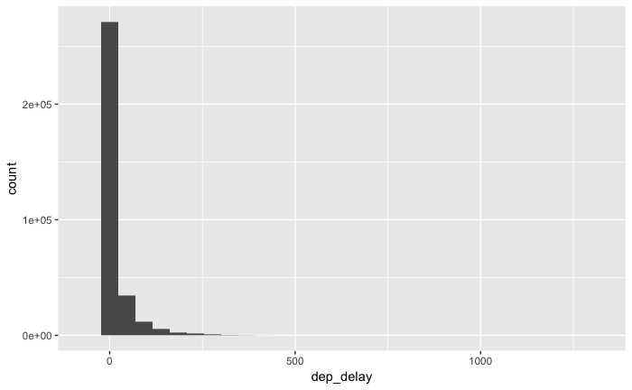

```r
ggplot(data = flights, aes(dep_delay)) +
    geom_histogram()
```

This looks kinda meh, lets change the bins.

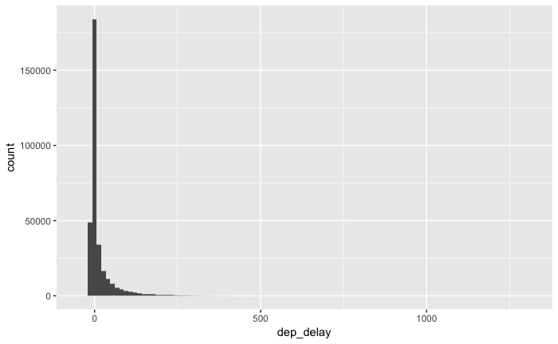

```r
ggplot(data = flights, aes(dep_delay)) +
    geom_histogram(bins = 100)
```

Another way to display a continuous variable is using a density plot

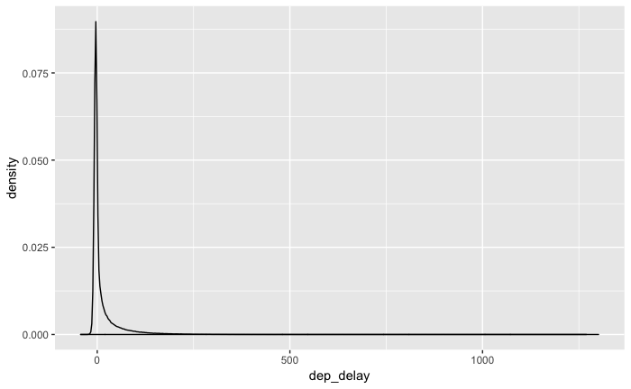

```r
ggplot(data = flights, aes(dep_delay)) +
    geom_density()
```

Lets look at a table as well. Here I cut (using `cut_width()`) the `dep_delay` variable and display the counts within. This is a table form of the histogram and is another way to get a sense for the spread of the data.

```r
flights %>%
    filter(dep_delay > 0) %>%
    mutate(binnedDelay = cut_width(dep_delay, width = 40)) %>%
    group_by(binnedDelay) %>%
    summarise(nObs = n())
```

| binnedDelay | nObs |
| --- | --- |
| [-20,20] | 66799 |
| (20,60] | 35052 |
| (60,100] | 13235 |
| (100,140] | 6197 |
| (140,180] | 3256 |
| (180,220] | 1810 |
| (220,260] | 952 |
| (260,300] | 521 |
| (300,340] | 286 |
| (340,380] | 138 |

[output cut: 18 more lines]

Now lets look at the `wind_gust` variable and explore this further.

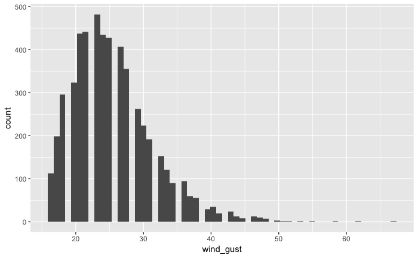

```r
ggplot(data = weather, aes(wind_gust)) +
    geom_histogram(bins = 60)
```

I am interested in seeing the unique values that wind gust takes.

```r
unique(weather$wind_gust)
```

```
 [1]       NA 20.71404 25.31716 26.46794 24.16638 23.01560 18.41248 16.11092 19.56326
[10] 27.61872 31.07106 28.76950 21.86482 17.26170 32.22184 29.92028 41.42808 39.12652
[19] 34.52340 37.97574 35.67418 33.37262 40.27730 36.82496 47.18198 44.88042 58.68978
[28] 55.23744 48.33276 51.78510 43.72964 42.57886 52.93588 49.48354 46.03120 66.74524
[37] 62.14212 50.63432
```

## Explore a relationship

We would like to explore the relationship between departure delay and wind gust. Our first task is to join in the weather data.

```r
weatheredFlights <- flights %>%
    select(origin, time_hour, dep_delay) %>%
    left_join(x = .,
              y = weather,
              by = c("origin", "time_hour"))
```

Next lets do a few simple plots.

[output not shown]

[output cut: 990 more lines]

[figure not shown]

This chart looks interesting/funky. Lets explore the number of observations within each of these groups.

| wind_gust | meanDelay | nObs |
| --- | --- | --- |
| 16.11092 | 8.825189 | 2016 |
| 17.26170 | 11.170406 | 3566 |
| 18.41248 | 14.123221 | 5047 |
| 19.56326 | 10.613985 | 5042 |
| 20.71404 | 13.132702 | 6810 |
| 21.86482 | 12.460524 | 6580 |
| 23.01560 | 13.313952 | 6929 |
| 24.16638 | 15.971026 | 6405 |
| 25.31716 | 13.262654 | 6324 |
| 26.46794 | 14.143187 | 5822 |

[output cut: 26 more lines]